# Single cell/nuclei QC and pre-processing

09 juni, 2026

#### In the chunck below, we will make Seurat objects of all samples (and apply basic filtering based on absolute median deviation to remove outliers):

##### Description:

- Genes (keep all, including 0-count genes):
  - For each object, we keep all genes, including genes with 0 counts across all cells. This is important for ambient RNA correction, because Cell Ranger’s filtered_feature_bc_matrix may drop genes that have zero expression across the filtered cells, while raw_feature_bc_matrix typically retains them. If you plan to use both matrices for ambient RNA detection/removal, it’s safest not to remove 0-count genes from the filtered matrix (to avoid a mismatch in the gene universe across matrices). Note: This is only a concern when you use both raw and filtered. If you work only with filtered_feature_bc_matrix from the start, then this issue is much less relevant.
- Cells (initially keep all, filter later):
  - For now, we keep all cells, including cells with 0 detected genes (i.e., no cell-based filtering at this stage). After ambient RNA removal, we will apply standard QC filters (e.g., keeping cells with at least x detected genes). In practice, you won’t see cells with 0 genes in filtered_feature_bc_matrix, because Cell Ranger already removes empty droplets and typically forces a minimum content threshold (often described as removing droplets with very low UMIs… exact thresholds can vary by version/settings).
- If starting from raw_feature_bc_matrix:
  - If you choose to work with the raw matrix, you can encounter droplets with very low content (e.g., cells with <100 genes and/or very low UMIs, such as <500 UMIs). In that case, we will remove obvious empty/near-empty droplets by default using a minimum detected genes threshold (default: min_genes = 100). This threshold can be adjusted, but it’s generally unlikely that true cells consistently fall below ~100 detected genes in typical 10x data.

##### Results:

- From now on you (the user) should keep an eye on the “the number of samples (cells)” in the chuck below. The number of samples in each filtering step will give you an idea how many cell you are losing in each step.

```
$`T1-SCI7T001-SCI5T001_23HJW5LT4_SAMP_5`
An object of class Seurat
17007 features across 10000 samples within 1 assay
Active assay: RNA (17007 features, 0 variable features)
 1 layer present: counts
```

- After MAD-based filtering, re-check sample sizes:
  - After filtering each object using an absolute median deviation (MAD) rule, inspect the number of remaining cells per sample and compare it to the previous step. This tells you how many cells were removed by this “extreme outlier” cleanup.
- What this step is meant to do:
  - The MAD threshold is chosen to remove only very extreme cells (rare cases that may slip through Cell Ranger’s filtering, or appear due to technical artifacts).
- Expected impact when using filtered_feature_bc_matrix:
  - When starting from Cell Ranger’s filtered matrix, this step usually removes very few cells (often ~0–50). In most datasets it won’t meaningfully affect downstream preprocessing (normalization, PCA, integration), because it targets only the most extreme tails.
- Why it matters much more for raw_feature_bc_matrix:
  - If you start from the raw matrix, you include many low-content droplets and some crazy borderline events. In that case, MAD filtering becomes far more impactful (and more useful too), because it helps eliminate obvious empty/near-empty droplets and other extreme artifacts before the rest of the pipeline. (Yes… unless you’re emotionally attached to empty droplets).
- Again, in the chunk below you should see haw many cells you lost. when compared to the previous step.

```
$`T1-SCI7T001-SCI5T001_23HJW5LT4_SAMP_5`
An object of class Seurat
17007 features across 9944 samples within 1 assay
Active assay: RNA (17007 features, 0 variable features)
 1 layer present: counts
```

#### QC plots:

##### Description:

- The number of unique genes detected in each cell:
  - Empty droplets and low quality cells often have very few genes and many 0 counts
  - Cell multiplets (doublets) often have very high gene count.
  - If you work with the filtered counts matrix as a starting point you will not find cells with <500 UMIs.
- User expectation:
  - In general, you should have an expectation of how many genes/UMIs the majority of your cells contain. Most of the time, The UMI counts per cell should be at least ~500 (and ~200 genes), that is considered the low end of what you should expect. However, cell that express extremely low number of genes will have UMI count below ~500. The same is true for a failed experiments with degraded RNAs. Thus the user should have an clear expectation.
- The percentage of reads mapped to the mitochondrial genome:
  - Dying or stressed cells often have a high mitochondrial fraction, which is commonly interpreted as relative enrichment of mitochondrial transcripts when cytoplasmic RNA is lost or reduced in damaged cells.
  - Note that for single-nuclei samples, MT genes are often still present, but at much lower quantities when compared to single-cell data.
  - Mitochondrial QC metrics are calculated as the percentage of total counts originating from a predefined set of mitochondrial features.
  - We define mitochondrial genes as those starting with “MT-” or “mt-” (species-specific naming), using Ensembl annotations to confirm the mitochondrial gene set for the species and then applying this rule consistently during QC.

##### Results:

- Barplots:
  - Representing the distribution and number of gene counts, transcript counts, and percentage of MT reads per cell. Generally, high fraction of MT reads in combination with low gene/transcript counts indicate stressed or dead cells. However, highly prolific stem or cancer-like cell are often rich in MTs, whereas some immune cells such as neutrophiles are in lower end of the spectrum in terms of gene and transcript counts.
  - The dashed red and orange lines represent the theoretical thresholds (Red: 10% MT, 200 nGenes, 550 nUMIs. Orange: 7.5% MT)

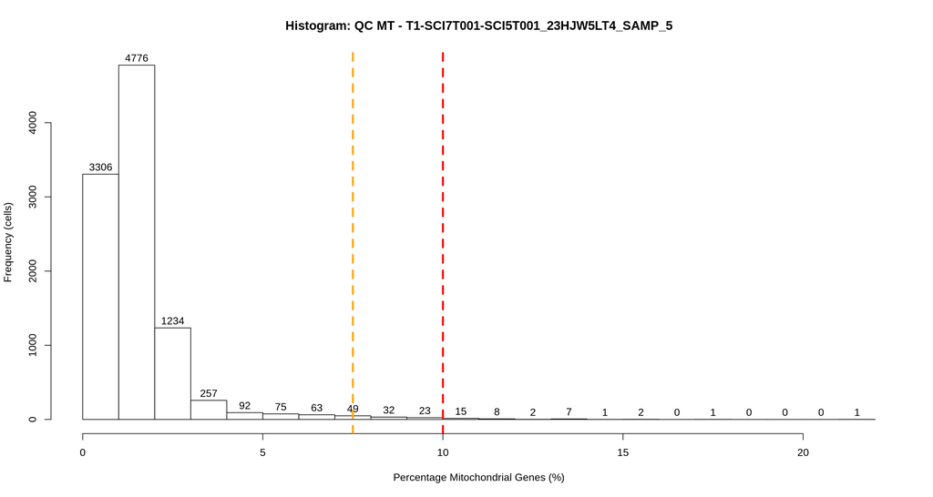

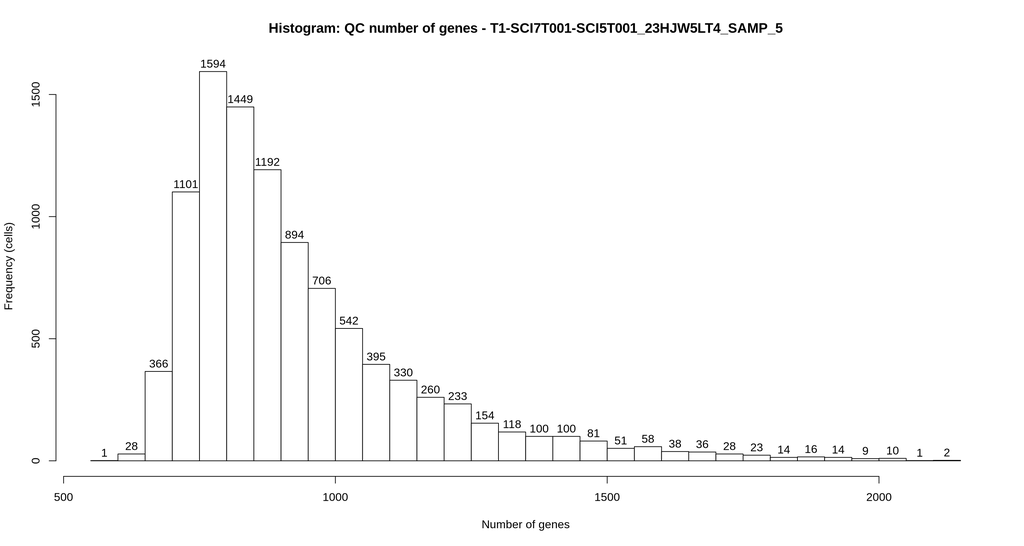

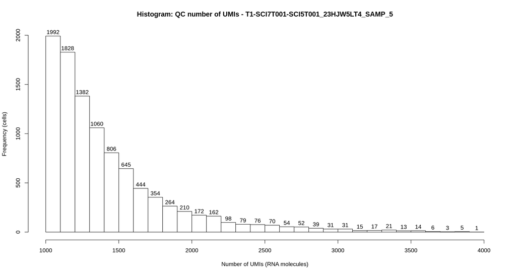

#### Here we will visualize the distribution of nGenes and nUMIs and the complexity of the cells:

##### Description:

- Terminology:
  - nFeature_RNA is the number of genes detected in each cell (violin plot).
  - nCount_RNA is the total number of molecules detected within a cell (UMIs) (violin plot).
  - percent.mt is the percentage of mitochondrial UMIs within a cell (violin plot).
  - Cell complexityis the proportion of nGenes raltive to the number of transcripts (RNA-molecules/UMIs).
  - Low complexity cells is a cell that has few genes, but more transcripts.
  - High complexity cells is a cell that more genes and less transcripts.
  - Dominant gene is a gene that has the hiighest expression in a cell relative to the other genes.

##### Results:

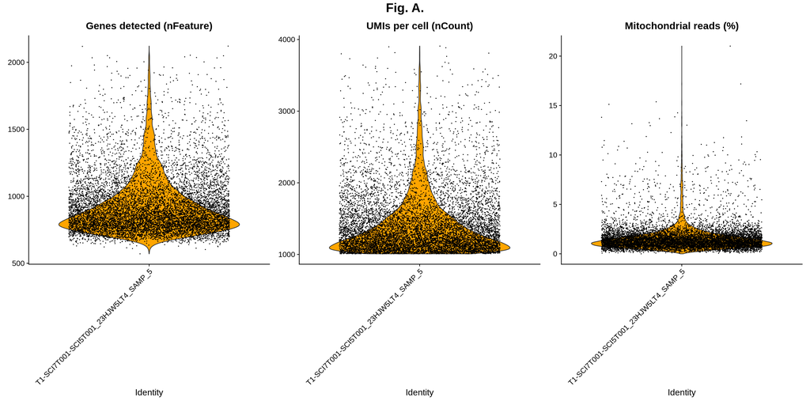

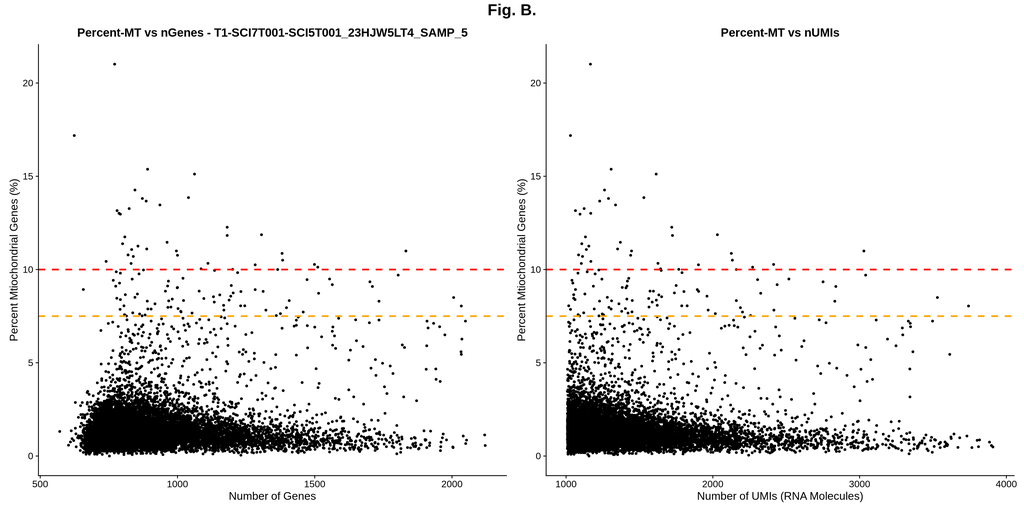

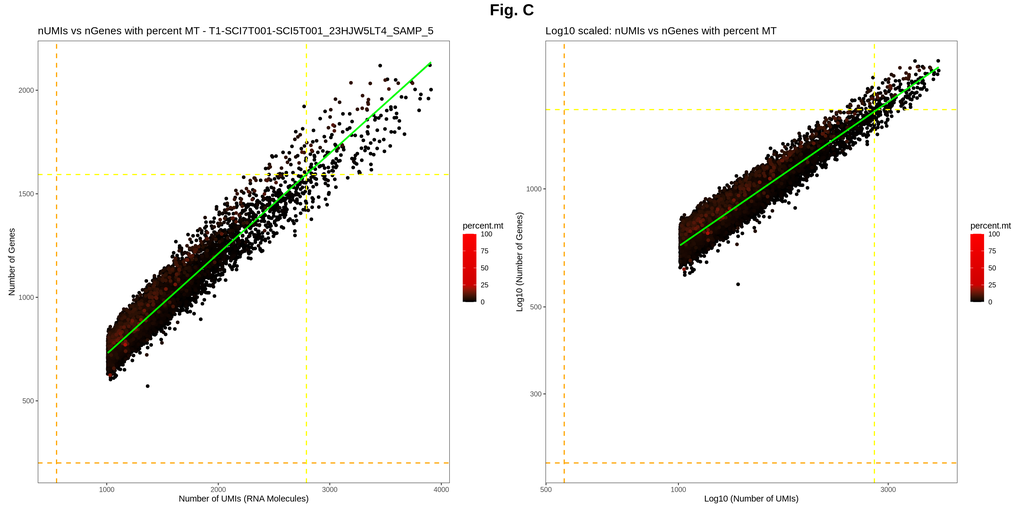

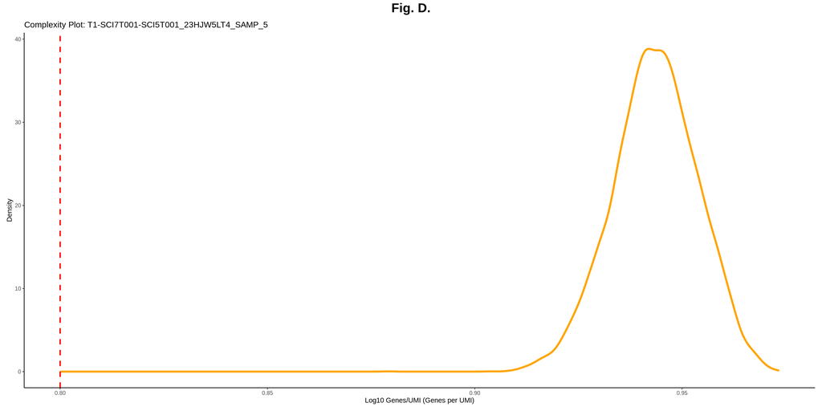

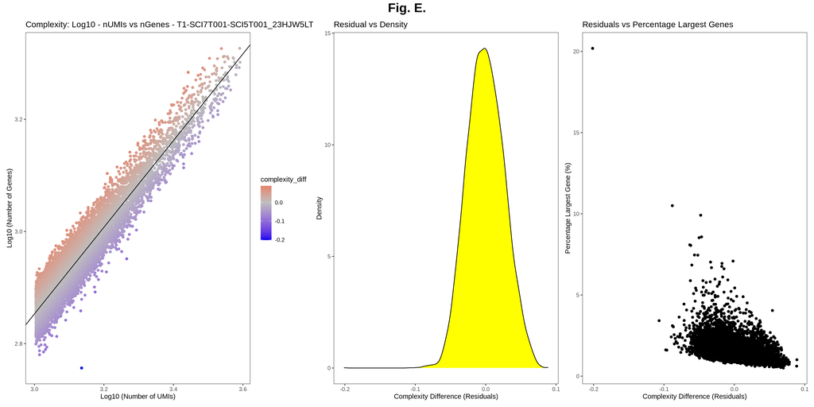

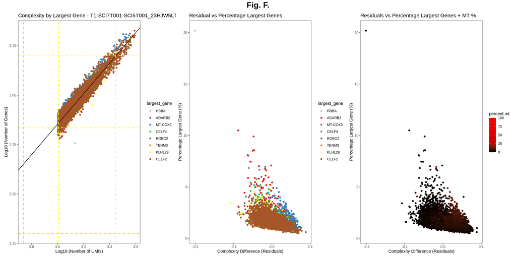

#### Visualize the highy variable genes:

##### Description:

- We first employ a log normalization method that normalizes the gene expression counts for each cell by the total expression and multiply this by a scale factor of 10,000 and log transform it to stabilize the variance so that larger values do not dominate over smaller ones.
- Then the top 2,500 genes (user-adjustable) with largest standardize variance will be selected automatically and used for the clustering. By selecting highly variable genes, we ensure that house-keeping genes with similar expressions across different cells do not interfere with the unsupervised clustering.
- Note that there is no definitive answer on how many genes one should include for clustering. Thus it is recommended to carefully consider the right number or by trying a range of 2000-5000 variable genes. Generally, low-complexity data (i.e. data with similar cells) will have lower number of variable genes when compared to complex tissue. By default, we will select 2500 highly variable genes.

##### Results:

- Most Variable Genes:
  - The plot should not looks like a flat line. There should be a clear distribution of the genes with the most highly variable on the top. If there are no highly variable genes in your data, then you are likely dealing with cells that have similar expression levels of the same genes. This can drastically impact the clustering and ambient RNA correction as most downstream steps are computed only on these genes.

```
Finding variable features for layer counts
```

```
When using repel, set xnudge and ynudge to 0 for optimal results
```

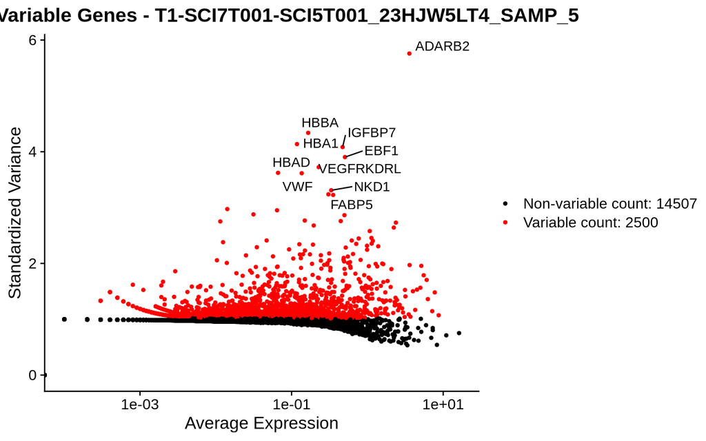

#### Unsupervised clustering: PCA

##### Description:

- Here, we carry out a linear dimensional reduction using PCA on the scaled data containing the most variable genes (as chosen before):
  - Before putting the highly variable genes into PCA, we will specifically scale those genes so that they have a mean of 0 and a variance of 1. More specifically, For each highly variable gene, a regression model is build using that gene’s expression level across all cells, and then shift the residual to zero and divided it by standard deviation.
  - We are essentially scaling and centering these genes in the dataset, which standardizes the range of expression values. This will regresses out unwanted sources of variation such as technical noise and each gene will contributes similarly to the downstream steps. As a result, the PCA and clustering will not be dominated by the signal of a few highly-expressed genes.
- The reason that we do a PCA is because we simply cannot work with this ultra high dimensional data for the downstream analysis. Instead we can look at which of the most variable genes explains most of the variance in the data.
- Note the PCA is a suitable method, but has some disadvantages:
  - (I still believe that ML would be a better option here, but it is not benchmarked in single-cell data as an alternative to PCA).
  - PCA is very popular, but fails to capture all signals considering that 2D dimensionality reduction cannot capture faint signal.

##### Results:

- PCA elbow plot: We will find the optimal number of dimensions for downstream analysis, based on:
  - PC where change in percent variation is more than 1%.
  - Or, PCs representing cumulative percent >90% and less than 5% associated with the single PC.
  - With each PC representing combined information of positive and negative correlated gene sets, the top PCs represent strong compression of the total dataset that can be used for further dimensionality reduction and clustering. If you find less than 10 PCs in the elbow plot, your data likely contains too few relevant genes for successful clustering. After all, we are looking for genes that can explain the variance in your cells, and if no such genes can be found (or too few of them) then the downstream steps will have difficulties to find the differences between your cells. However, if you are working with low-complexity data (e.g. similar cell types in different biological states) then you should to find fewer number of PCs.
  - The dashed red line in the plot shows the optimal number PC dimensions.

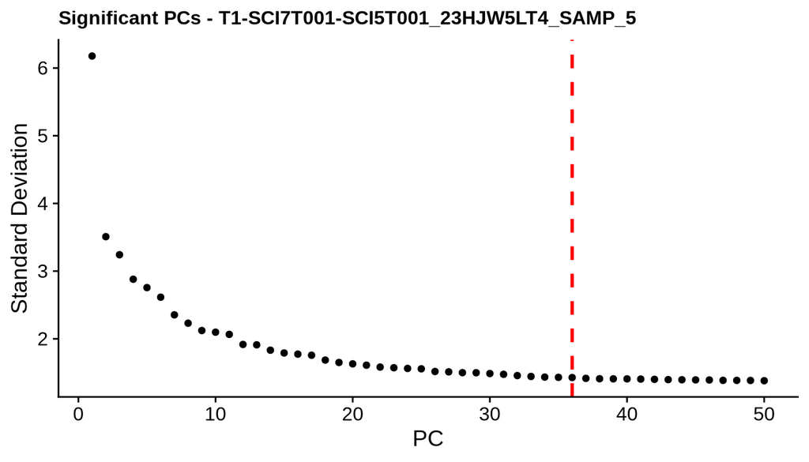

#### Final clustering (KNN (SNN)) using the most explained PCs and projection onto UMAP:

##### Description:

- Original Louvain algorithm (graph-based clustering on PCs):
  - Again, after normalization and variable feature selection, we ran PCA on the most variable genes. Each principal component (PC) is a weighted (linear) combination of many genes, and the first PCs capture the strongest sources of variation in the dataset (often biology, but sometimes technical effects such as library size or mitochondrial content).
    - Based on the Euclidean distance in PCA space, we construct a K-nearest neighbor (KNN) graph (k = 20 by default). We then refine the connectivity between cells by weighting edges using the overlap in their nearest-neighbor sets (shared neighborhoods), commonly quantified with the Jaccard similarity (i.e. two cells are considered more strongly connected if they share many of the same neighbors).
    - Using this refined neighbor graph, the Louvain community-detection algorithm iteratively merges and rearranges cells into communities until the partition converges (clusters are groups of cells that are more connected to each other than to the rest of the graph).
    - We then compute a UMAP embedding for visualization using the same PC-based neighbor structure. Importantly, clustering is performed on the PC/KNN graph, while UMAP is only a non-linear 2D projection used for plotting (UMAP does not create clusters, it visualizes them. But keep in mind that the UMAP embeddings can be used by downstream analysis tools, such Monocle).
    - Cluster granularity is mainly controlled by (i) the number of PCs used, (ii) the neighbor graph parameters (k), and (iii) the Louvain resolution parameter. In our experience, a resolution of 0.8 gives a reasonable number of preliminary communities across both high-complexity data (e.g. porcine ileum with immune populations) and lower-complexity data (e.g., organoid/tissue with fewer transcriptionally distinct populations).
    - A resolution of 0.8 is therefore set as the default. However, more work is required to develop an adaptive resolution strategy, because this parameter strongly affects the number of preliminary clusters that will later be used by the ambient RNA correction algorithm.
    - As an experimental feature, the user may change the resolution, which will change the number of clusters (not recommended for standard use). If you obtain too few clusters with the default settings, it can be worth trying a resolution >0.8. Too few clusters may bias ambient RNA correction because cluster-specific expression profiles become overly broad (more on this later).
    - (NOTE: Extensive documentation and mathematics will follow in the final pipeline documentation)

##### Results:

- UMAP plots: number of genes/UMIs/MTs are shown per cell within each cluster:
  - These plots provide a quick overview of which clusters [Fig. A] contain cells with low, medium, or high nFeature_RNA (genes) [Fig. B], nCount_RNA (UMIs) [Fig. C], and percent.mt (mitochondrial fraction) [Fig. D].
    - High genes or UMIs are not automatically “bad” (some real populations are transcriptionally active, cycling, or naturally RNA-rich), but they are still highlighted (purple) so potential doublet-like or unusually active groups are easy to spot and investigate.
    - In partially failed experiments (e.g., widespread low RNA content due to degradation, harsh dissociation, or nuclei damage), these plots can show whether the problem affects all clusters or only specific clusters. If the same clusters also show elevated percent.mt, this strengthens the interpretation that those cells are low-quality or dying (especially for single-cell data; for single-nuclei the MT signal is typically lower overall).
    - How many clusters do you observe in total? Based on what you know about your tissue, chemistry (single-cell vs single-nuclei), and expected cell-type diversity, do you expect more or fewer distinct communities?

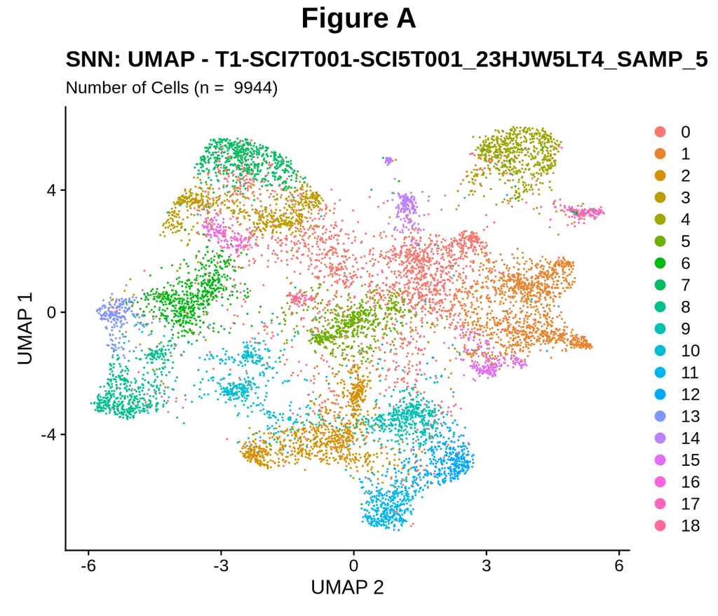

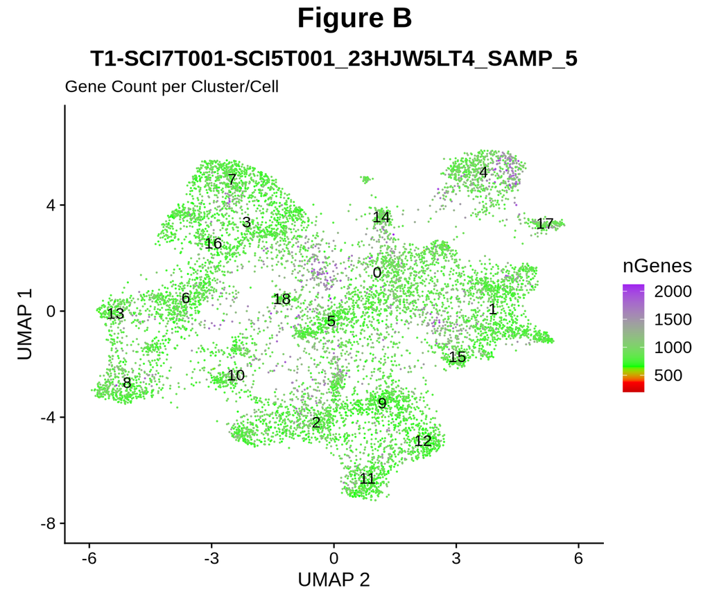

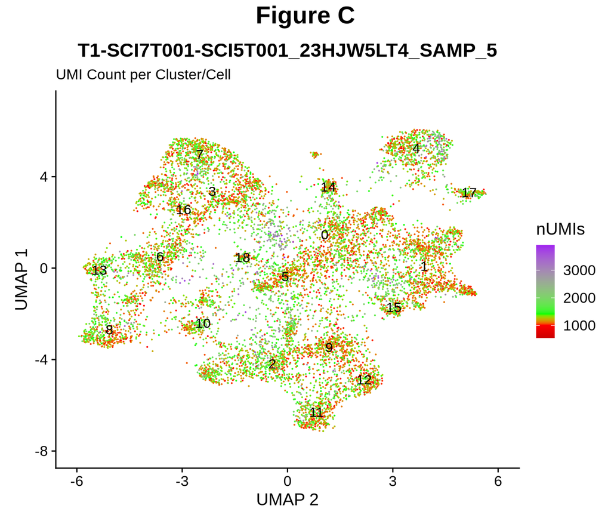

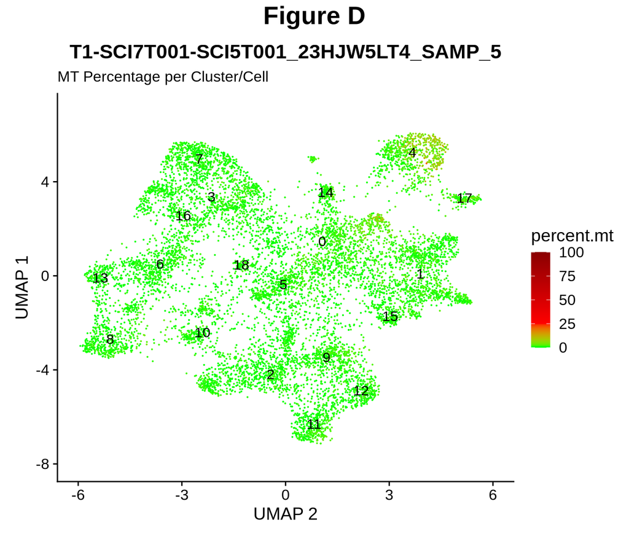

#### SoupX Ambient RNA Removal:

##### Description:

- Terminology:
  - Total contamination (background profile): the estimated gene-wise composition of ambient RNA in the channel, learned primarily from (semi)-empty droplets in the raw counts matrix. In other words, it describes “what the soup looks like” (which genes make up the ambient pool, and in what proportions).
  - Contamination fraction (cell-specific): the estimated fraction of transcripts in each cell that are derived from the ambient background. SoupX infers this by looking for expression of cluster-enriched marker genes in clusters where they should not be present, under the assumption that this signal is best explained by ambient RNA leaking into droplets. In simple terms, it estimates “how much soup is in each droplet”.
- The aim of SoupX is to estimate what fraction of transcripts in each droplet are ambient and to generate a corrected gene count matrix with the contaminated counts removed. The algorithm follows these steps
  - It first calculates the expression profile of the total contamination by estimating the ambient RNA expression from the raw counts-matrix obtained from the CellRanger output. Regardless of the user choice, in this step we always utilize the raw counts as this data contains information of empty droplets, which is an excellent candidate to analyze cell-free droplets that may contain ambient RNA for each gene. (If for some reason the raw counts are not available, SoupX will not run, and the pipeline will continue without the correction of ambient RNA).
  - 1. Estimate the ambient background (“total contamination”): SoupX first estimates the ambient RNA expression profile using the raw_feature_bc_matrix from the Cell Ranger output. This step relies on raw counts because the raw matrix contains many empty and near-empty droplets, which provide direct information about cell-free ambient RNA for each gene. Regardless of the users starting choice (raw vs filtered), we always use the raw matrix for this background estimation. If the raw matrix is not available, SoupX cannot be run and the pipeline proceeds without ambient RNA correction.
  - 2. Estimate cell-specific contamination fractions using clusters: once the background profile is known, SoupX uses the previously computed cell clusters to estimate how much ambient RNA is present in each droplet. The idea is to identify genes that are strongly enriched in one cluster but should be absent (or near-absent) in others, and then measure their “unexpected” expression outside their home cluster. This off-target signal is used to estimate the contamination fraction per cell.
  - 3. Subtract contaminated counts and return corrected matrix: with (i) the background profile and (ii) the cell-specific contamination fractions, SoupX estimates how many counts for each gene in each cell are likely explained by ambient RNA, and subtracts these counts to return an ambient-corrected count matrix.
- Practical note on clustering and low-complexity data:
  - SoupX depends on having a reasonable number of clusters, because it needs cluster-specific marker genes to detect off-target expression patterns. If you obtain too few clusters (often due to low complexity, few highly variable genes, or insufficient PC dimensions), contamination estimation can become less reliable.
  - In such cases, it may help to increase the clustering resolution (e.g. >0.8) to obtain more clusters, and then reassess whether SoupX behaves more sensibly. However, a very low number of clusters can also reflect true biology (e.g. very homogeneous organoids) or technical failure, but if increasing resolution does not improve interpretability, you may consider skipping ambient RNA correction for that dataset.
- Important note when working with raw counts:
  - When using the raw_feature_bc_matrix as input, the pipeline typically applies a minimal droplet filter (e.g., removing droplets with <100 detected genes). This is less aggressive than Cell Ranger’s filtered_feature_bc_matrix, where many near-empty droplets have already been removed (often corresponding to very low UMI droplets).
  - Therefore, do not be surprised if estimated ambient contamination appears higher when starting from raw counts. The raw matrix contains far more low-content droplets, which makes ambient RNA more visible. In most cases the correction still works well, unless the experiment is severely compromised (e.g., strong RNA degradation leading to widespread low-content profiles).

##### Results:

- Contamination Density plot (first plot):
  - This plot shows the probability distribution of the estimated contamination fraction. The density is computed from the aggregated evidence across cluster-marker genes that were used to infer contamination (i.e. marker genes that should be high in one cluster but low/absent in others).
  - The final contamination fraction is chosen as the value with the highest probability (shown as a vertical red line), because this represents the most supported “global” contamination level given the marker evidence.
  - A well-behaved SoupX run typically shows a clear peak (one contamination fraction is clearly preferred). In contrast, a very flat distribution (no clear peak) suggests SoupX could not identify a consistent contamination level (often due to too few informative markers, too few/too broad clusters, or very homogeneous/low-complexity data), and the correction may be unreliable.
- Barplot:
  - This barplot summarizes the estimated percentage of ambient RNA detected and removed from the dataset.
    - As a rough reference, contamination levels around ~5–15% are commonly observed in many fresh single-cell tissue datasets, while nuclei datasets often show different behavior depending on the preparation and the degree of ambient RNA present. The key point is not the exact number, but whether it matches your expectations and whether the corrected expression patterns look more biologically plausible.
- Affected SoupX Marker Genes (UMAP):
  - These UMAPs visualize expression of the marker candidates that SoupX used to estimate contamination fractions, shown before and after correction (pre- vs post-SoupX).
    - By default, the top 3 marker genes are shown, but the user can choose how many markers to display (0–100). This is useful to confirm that off-target “leakage” of markers into the wrong clusters decreases after correction, while true marker expression in the correct cluster is preserved.
- Affected User Genes (UMAP):
  - These UMAPs display pre/post correction for user-defined genes of interest.
    - To use this feature, the user must provide a list of genes in the gene.txt file (see pipeline documentation on GitHub). This is especially useful when you want to verify that biologically important genes (e.g. key markers) were not overly removed, or when you suspect specific genes are heavily affected by ambient RNA.
- Most Affected Genes (UMAP):
  - These UMAPs visualize genes that experienced the strongest correction overall.
  - Because many of the “most affected” genes are often lowly expressed and present in relatively few cells, these plots may be less interpretable than marker-based plots. For that reason, this option is disabled by default, but the user can enable it and choose how many genes/plots to show.
- Colors in the UMAP plots:
  - Red dots: the gene was strongly corrected in that cell (a substantial fraction of counts removed).
    - White dots: the gene was weakly corrected in that cell (a small change).
    - Grey dots: no correction occurred for that gene in that cell (no counts removed).

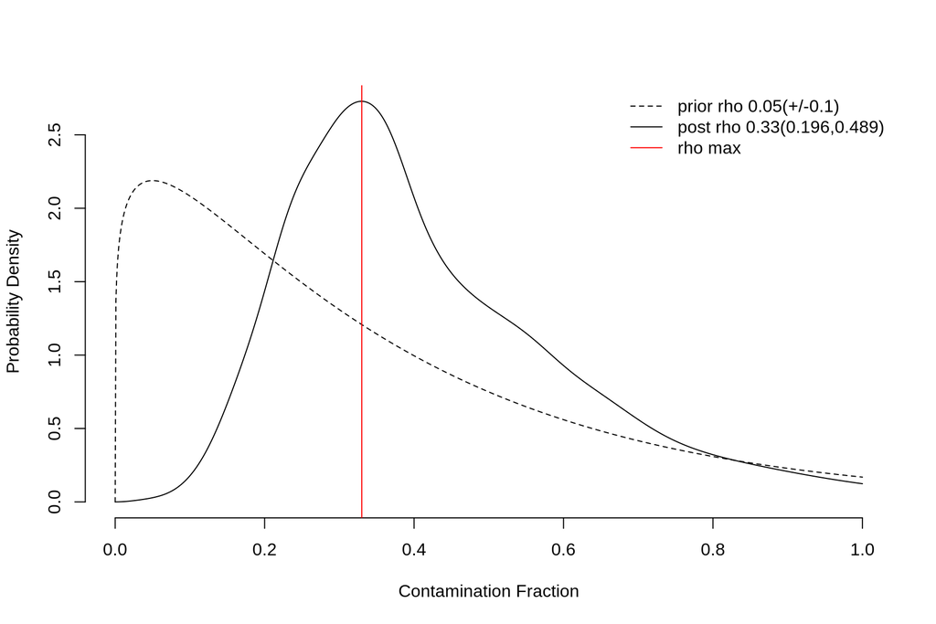

```
[1] "Percentage of Ambient RNA (UMI) removed: 33 T1-SCI7T001-SCI5T001_23HJW5LT4_SAMP_5"
```

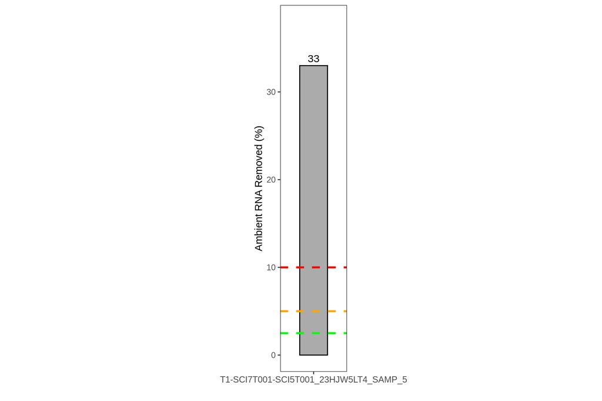

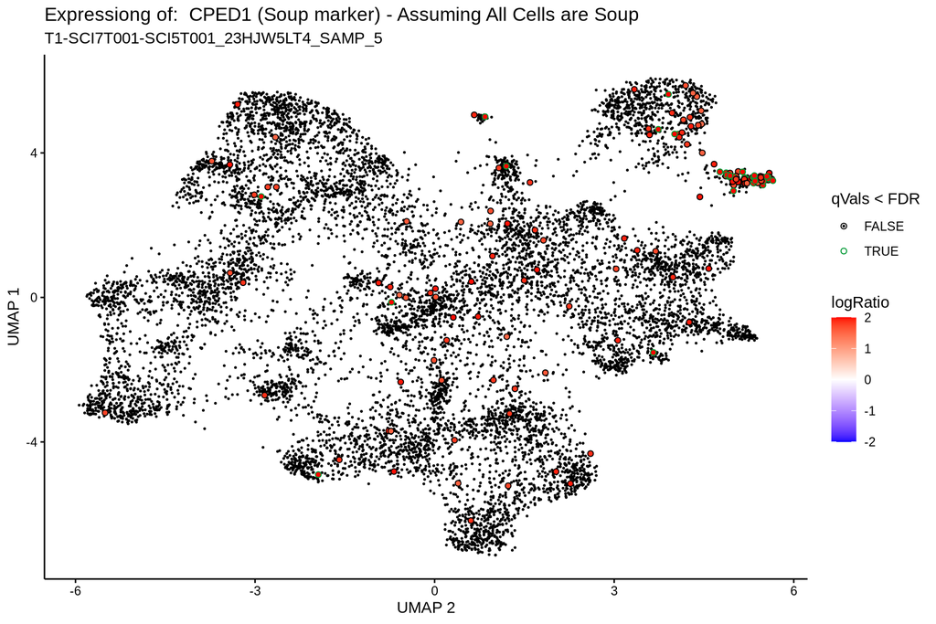

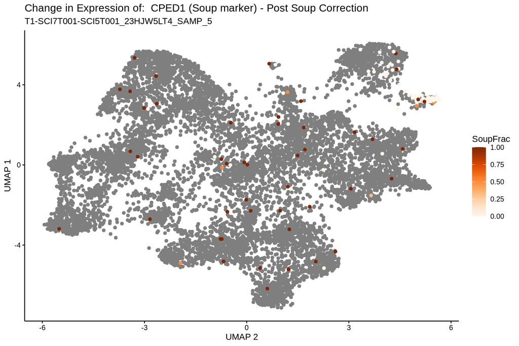

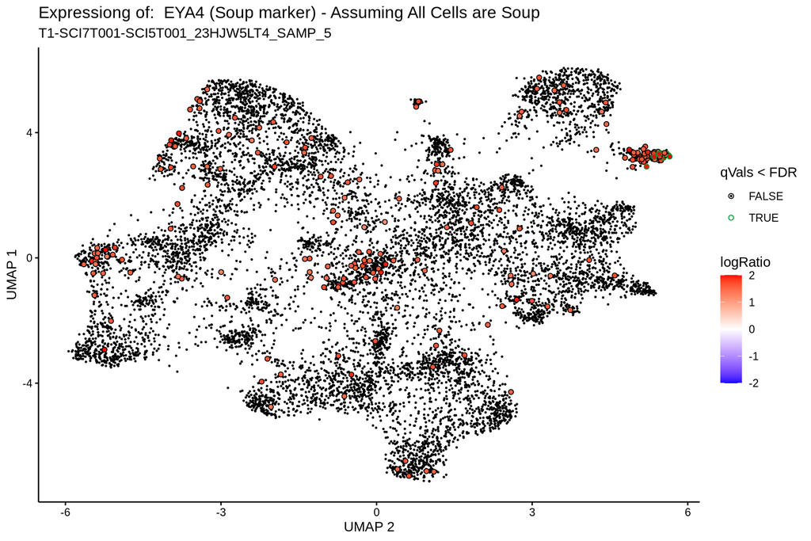

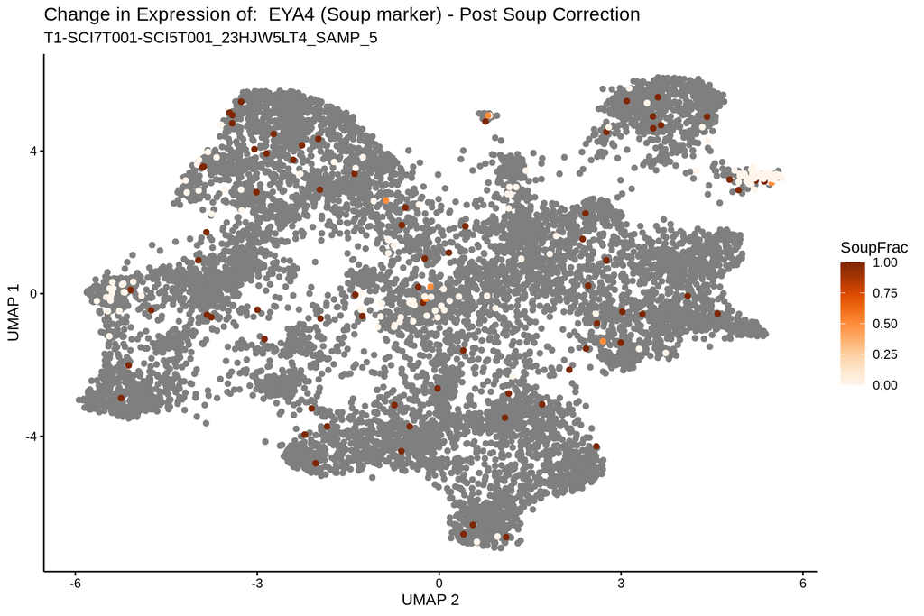

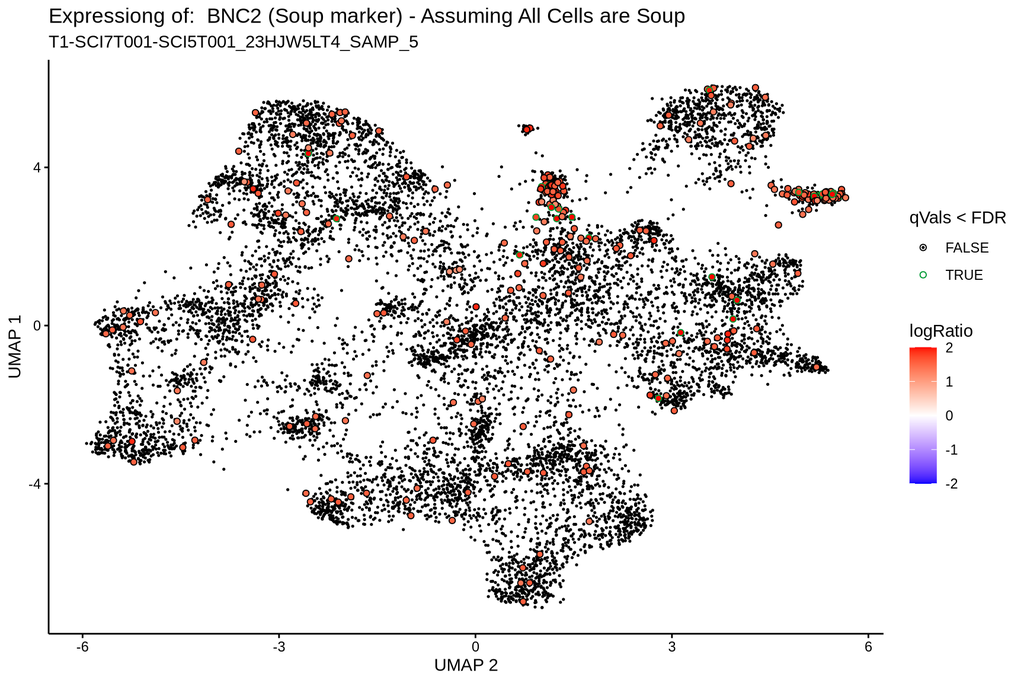

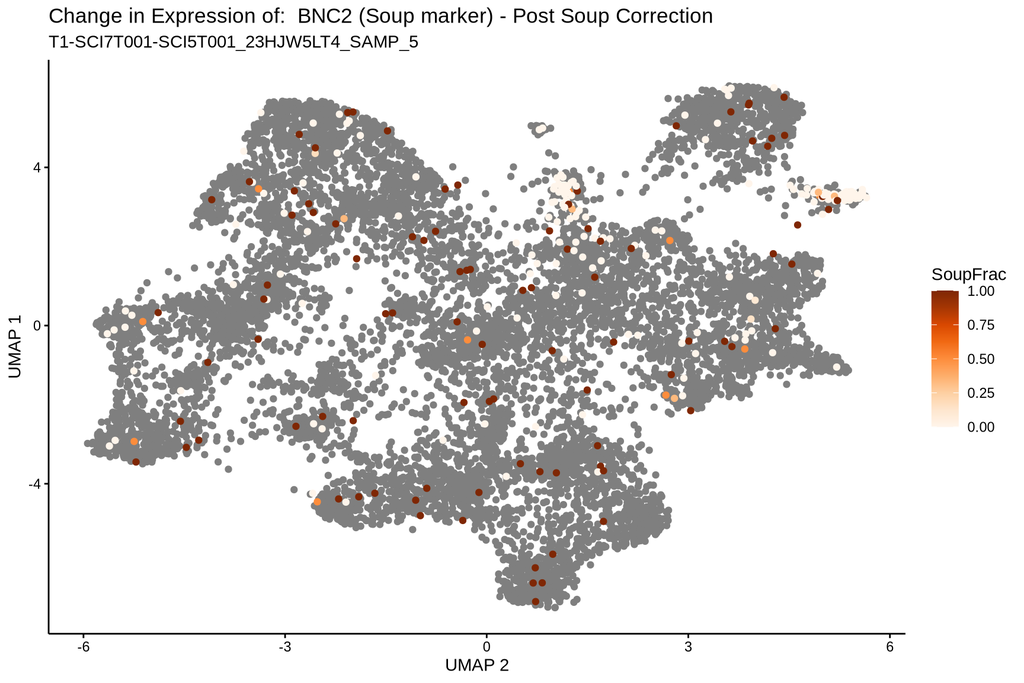

#### Extensive filtering

##### Description:

- By default, we apply an automatic “extensive filtering” step to remove the most obvious low-quality cells after ambient RNA correction:
  - Cells with percent.mt > 10% are removed by default (this is a practical guideline and can be adjusted for tissue type and for single-cell vs single-nuclei data).
  - For library size and complexity, we apply lower-bound filtering using quantiles: cells with nFeature_RNA and/or nCount_RNA below the 2% quantile are removed as a default lower limit. This removes the extreme low-content tail while remaining relatively conservative across different datasets.
  - By default, we do not filter on the upper tail (high nFeature/nCount), because these cells can include true biological populations with high RNA content, but also doublets/multiplets. Instead of removing them by force, we prefer to keep them and detect doublets later using DoubletFinder.
  - If the user has prior knowledge about expected ranges, filtering can optionally be applied using user-defined cutoffs for nFeature_RNA, nCount_RNA, and percent.mt. The user can also adjust the lower/upper quantiles used for automatic thresholds.
  - Important: applying aggressive upper-limit filters (either by hard cutoffs or by upper quantiles) can remove true doublets before they are detected algorithmically, and can also remove real high-RNA cell types. Therefore, upper filtering should only be used when clearly justified by the biology and/or known technical artifacts.
  - Finally, as a last sanity filter, we optionally filter on expression complexity using log10GenesPerUMI = log10(nFeature_RNA) / log10(nCount_RNA). This removes cells with disproportionately many UMIs coming from too few genes (low complexity), which is often a signature of stressed/degraded profiles or technical artifacts. When enabled, we apply a soft threshold of >= 0.8 by default and report how many cells were removed. (This threshold is intentionally conservative and is not meant to replace biological interpretation.). This parameter is user adjustable (see pipeline documentation).
- Note that these default parameters have performed well in both high-complexity datasets (e.g. porcine ileum/colon tissue with diverse immune populations) and lower-complexity datasets (e.g. porcine ileum organoids), while generally preserving cell-type diversity (including rare immune subsets that may have relatively low genes/UMIs).

##### Results:

- Now take a close look at the chunk below: how many cells do you have, and is this number substantially lower than in the previous step?
  - (The cells are called ‘samples’).
  - (Ignore the inflated number of ‘feautures’. These are the number of genes from two assays in Seurat).

```
featureLOW not manually set -> using feature.quantile.low = 0.02 (2.0%) => 684 to compute featureLOW.
```

```
Given the good coverage (min number of UMIs >= 1000, min(nCount_RNA) >= 1000), thus countLOW = min-1 = (1008).
```

```
featureHIGH not manually set -> using feature.quantile.high = 1 (100.0%) => 2121 to compute featureHIGH.
```

```
countHIGH not manually set -> using UMI.quantile.high = 1 (100.0%) => 3908. to compute countHIGH
```

```
Complexity filtering skipped (UMI.feature.complexity was not set).
```

```
QC filtering: kept 9711/9944 cells (removed 233).
```

```
$`T1-SCI7T001-SCI5T001_23HJW5LT4_SAMP_5`
An object of class Seurat
34014 features across 9711 samples within 2 assays
Active assay: RNA (17007 features, 2500 variable features)
 3 layers present: counts, data, scale.data
 1 other assay present: original.counts
 2 dimensional reductions calculated: pca, umap
```

#### Multiplet Removal

##### Description:

- DoubletFinder (core idea):
  - DoubletFinder starts by creating artificial doublets by randomly combining expression profiles of pairs of real cells. By default, we generate artificial doublets at a rate of ~1 per 4 real cells (i.e., we intentionally spike many synthetic doublets into the dataset). This creates a mixed dataset where synthetic doublets sit alongside real droplets, mimicking what happens when two cells end up in the same GEM.
  - Next, DoubletFinder runs PCA again using the same optimal number of PC dimensions determined earlier (from the unsupervised clustering step). It then builds a KNN structure in PC space and asks a simple question: does a given real cell live in a neighborhood that looks “doublet-like” (i.e. enriched for artificial doublets)?
  - This is done through a parameter sweep (commonly over pK) and is relatively computationally expensive because neighbor relationships are repeatedly recalculated. For this reason, the pipeline allows multi-core execution (4 cores by default).
  - After the sweep and classification, the artificial doublets are discarded, and a user-expected proportion of predicted real doublets is removed from the dataset.
- Expected doublet rate (anchored to 10x guidance):
  - For the 10x Single Cell 3’ Gene Expression chemistry, the expected fraction of multiplets increases approximately linearly with the number of recovered cells. To avoid over- or under-calling doublets, we use the 10x-provided recovered-cells vs multiplet-rate relationship (from their documentation) and fit a simple linear model that converts “cells recovered” into an expected doublet fraction.
    - This expected fraction is then used to decide how many of the most doublet-like cells should be labeled/removed (instead of guessing blindly). (10x reference: https://kb.10xgenomics.com/hc/en-us/articles/360001378811-What-is-the-maximum-number-of-cells-that-can-be-profiled-)
- Practical notes (speed + interpretation):
  - Please increase the number of cores for this step if you have many cells, because the parameter sweep (finding KNN neighborhoods repeatedly in PC space) can take substantial time.
  - The number of cores should not exceed the resources allocated to the pipeline (e.g., SLURM/CPU limits). If you request more cores than available, DoubletFinder may crash or stall due to resource contention.
  - Keep in mind: some doublets are easy (two very different cell types), while homotypic doublets (same cell type) are harder to detect because they resemble real cells with higher RNA content. This is one reason we avoid aggressive upper filtering of nUMI/nGene earlier and rely on DoubletFinder to flag these cases algorithmically.

##### Results:

- Doublet UMAP plot [Fig. A]:
  - This UMAP highlights cells predicted as doublets within the preliminary clustering structure. Predicted doublets often appear on the edges of clusters or in “bridge” regions between two populations, because their expression profile can look like a mixture of two cell states.
  - Keep in mind that this is not a strict rule: homotypic doublets (same cell type) can fall inside a cluster and be harder to spot visually.
- Violin plots [Fig. B, C]:
  - These violin plots compare singlets vs predicted doublets across QC metrics such as nFeature_RNA (genes) [Fig. B] and nCount_RNA (UMIs) [Fig. C].
  - In many datasets, doublets tend to have higher genes and UMIs than singlets, because two captured cells contribute more RNA. However, high genes/UMIs alone is not proof of a doublet, since some true cell types are naturally high-RNA (cycling, developing, activated, etc.).

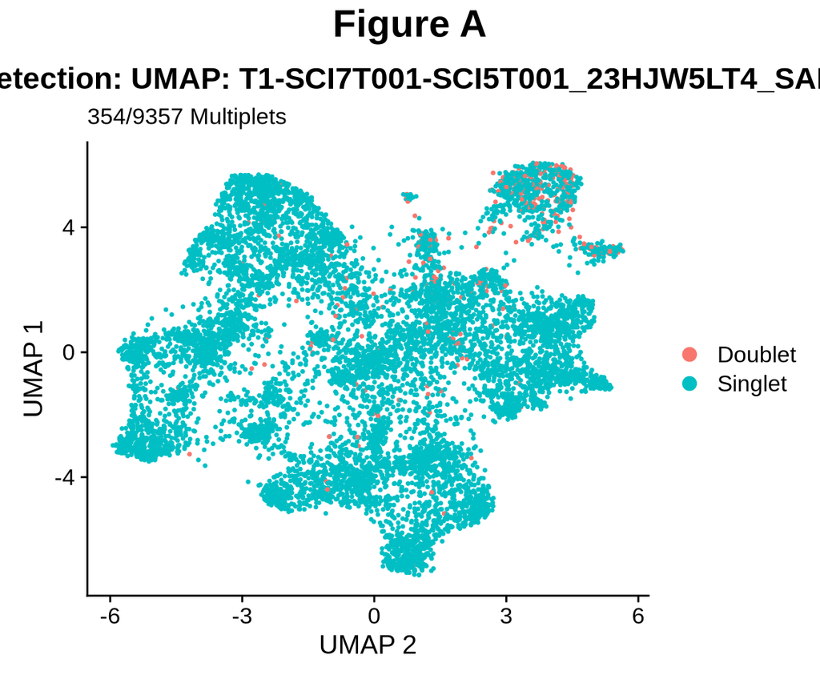

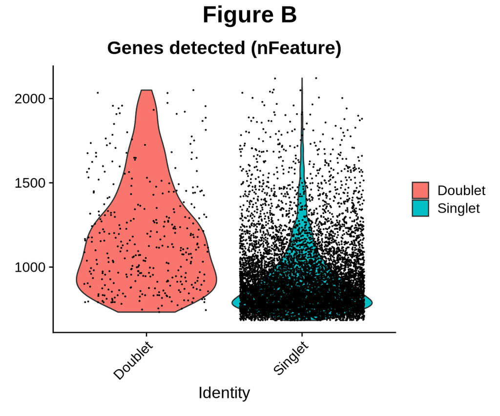

[figure not shown]

```
T1-SCI7T001-SCI5T001_23HJW5LT4_SAMP_5
Doublet Singlet
    354    9357
```

#### Final filtering and QC plots

##### Results:

- In the chunk below, we apply a final filtering step by removing the identified multiplets (doublets) from the dataset.
  - You can now directly compare the number of cells before vs after doublet removal. This gives you a clear sense of how aggressive the full QC pipeline was (ambient correction + QC filtering + doublet removal).
    - Likewise, you should compare the QC plots to the earlier versions. Do you see improvements (e.g., fewer extreme low-quality cells, reduced MT-driven artifacts, cleaner genes/UMIs distributions)?
    - Remember that you can always adjust parameters and re-run the pipeline if the filtering appears too strict or too permissive.
- It is strongly recommended to attempt an initial cell-type annotation using the pre-processed data and check whether you recover the expected cell types (and roughly the expected proportions).
  - If you suspect you are losing rare, low-RNA populations (low genes/UMIs), consider starting from the raw_feature_bc_matrix. This may recover cells that were removed by Cell Ranger’s filtered matrix (which often excludes very low UMI droplets).
  - When starting from the raw matrix, the pipeline applies a minimal droplet filter of <100 detected genes (default). This is meant to remove obvious empty/near-empty droplets while still being less aggressive than the filtered matrix.
  - In most 10x datasets, even rare real cell types typically exceed ~100 detected genes, but you may change this threshold if you have a strong biological reason.
  - Important: do not apply (or change) this <100 genes droplet filter when working with the filtered_feature_bc_matrix. The filtered matrix has already enforced its own cell-calling thresholds, thus adding an additional hard minimum can unnecessarily remove genuine low-content cells and reduce sensitivity for rare populations. (THUS, NEVER TOUCH THIS PARAMETER IF YOU AEE WORKING WITH THE FILTERED COUNTS MATRIX! You will always lose cells that contain few genes/transcripts).

```
$`T1-SCI7T001-SCI5T001_23HJW5LT4_SAMP_5`
An object of class Seurat
34014 features across 9357 samples within 2 assays
Active assay: RNA (17007 features, 2500 variable features)
 3 layers present: counts, data, scale.data
 1 other assay present: original.counts
 2 dimensional reductions calculated: pca, umap
```

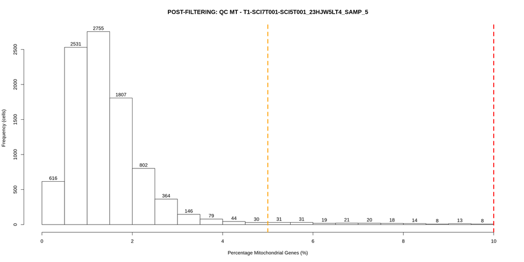

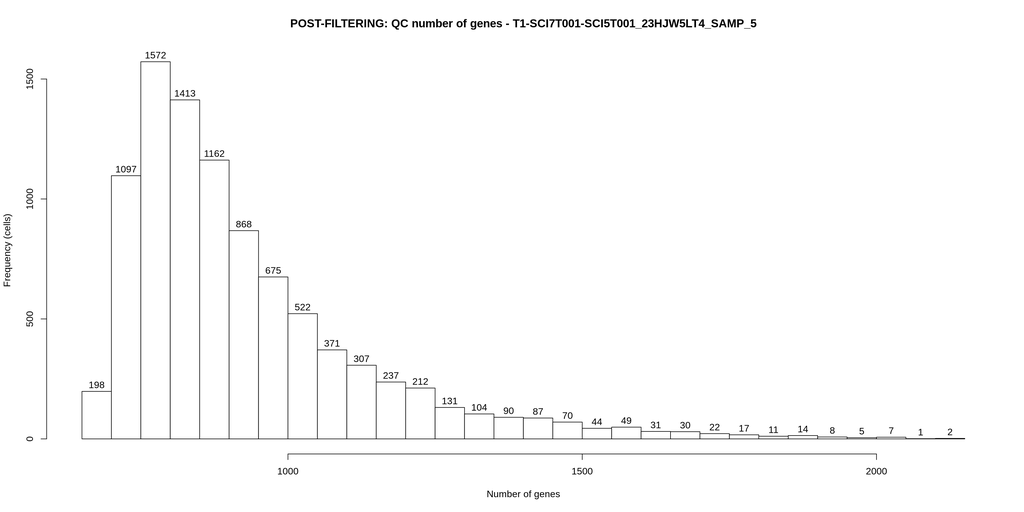

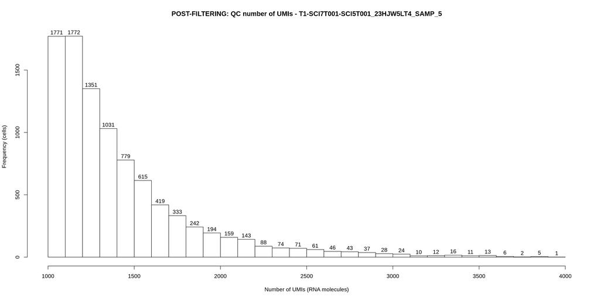

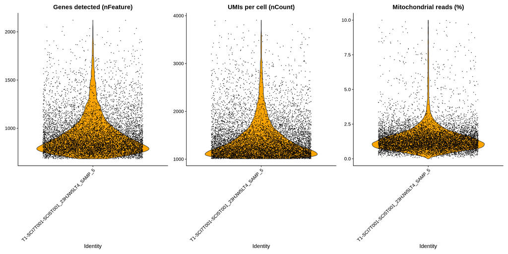